# The Type of People Using Public Transport

## What form of transport was the most popular and what ages were the passengers tend to be around?

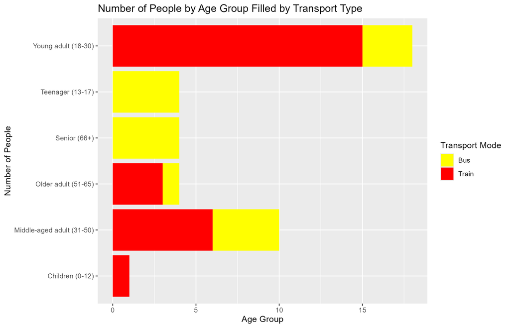

My first shows the age groups that were most observed people on public transport, as I believed this to be an interesting start to the charts.

## What about their ages by form transport?

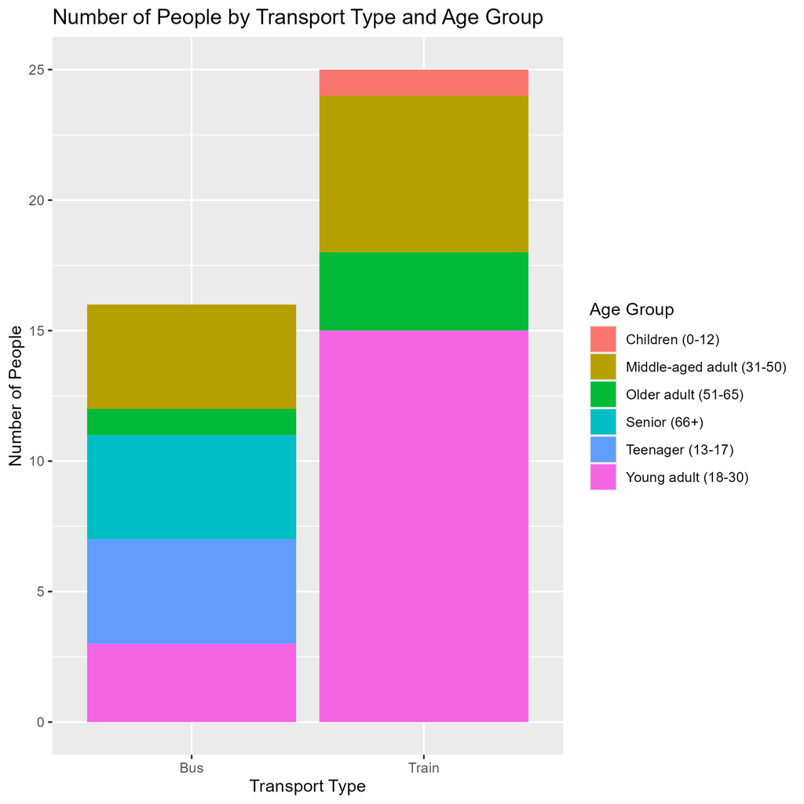

I then went to show how the age groups would look if I had separated the groups into the transport type that they were observed in.

## The activities they liked to do while travelling

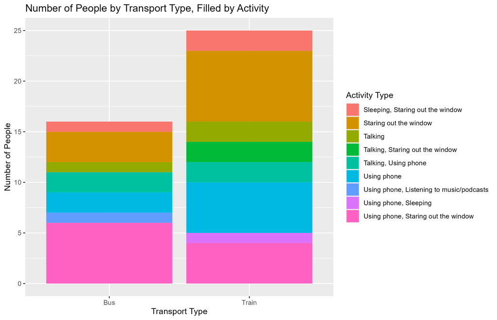

This shows the overall activities that passengers would partake in when travelling on public transport.

## Issues I came across in the project

[figure not shown]

## Why I couldn’t use a chart that relies on a numerical factor

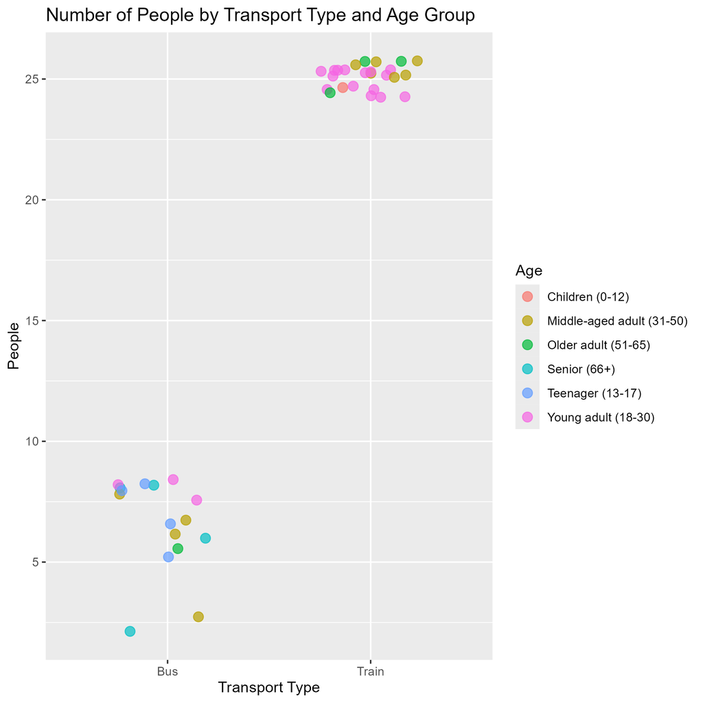

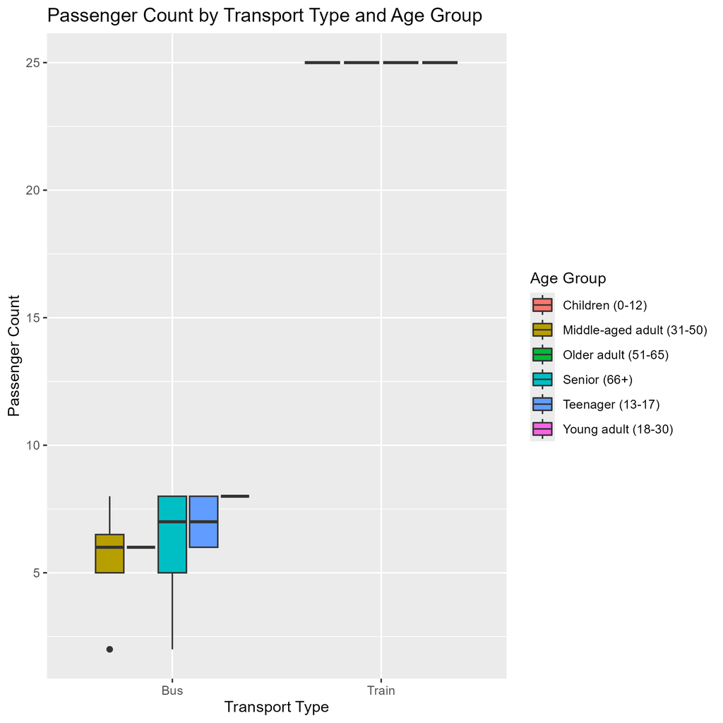

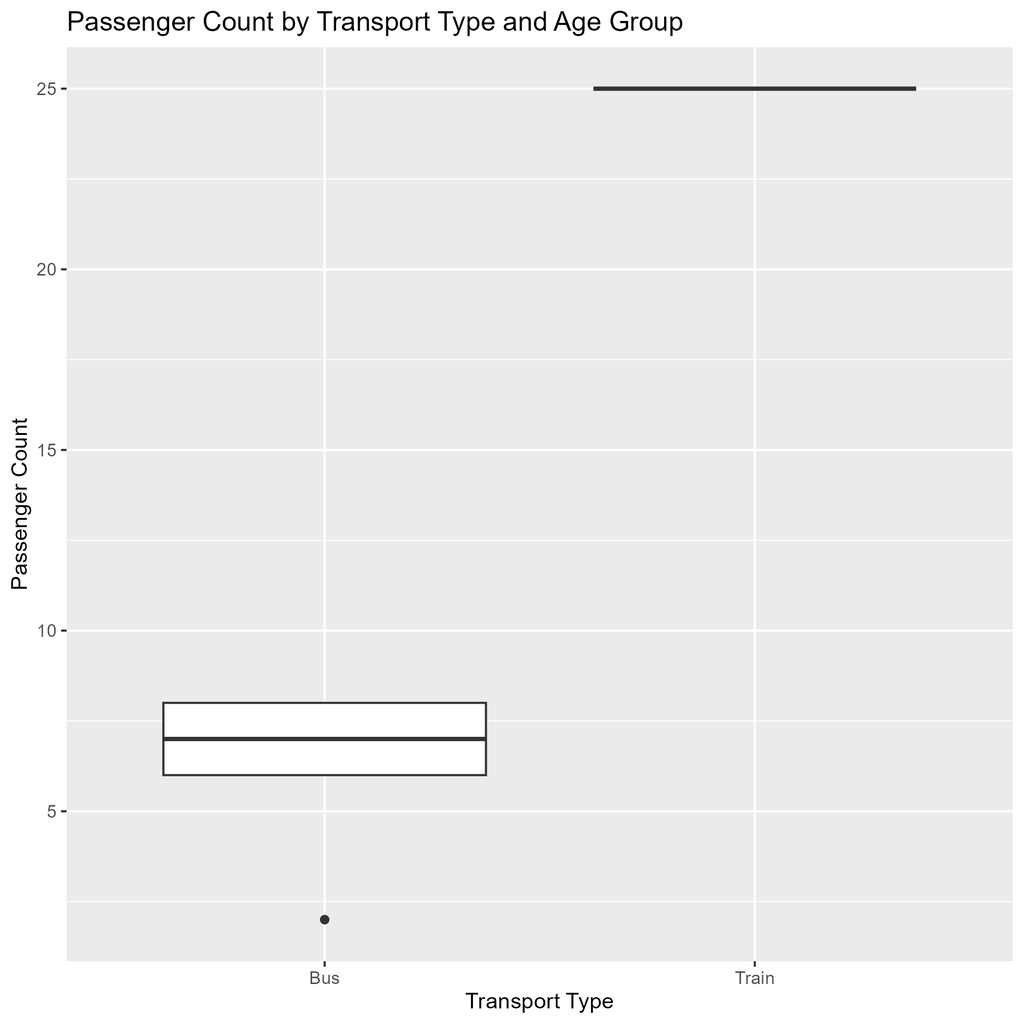

The numerical value that I recorded was not very compatible with the required second graph that did not use geom_bar() as my numerical value recorded the **TOTAL** number of passengers on the vehicle and did not have a dynamic way of recording the count of the passengers. This led to multiple types of other graphs, such as box and whisker graphs, to appear as a single line with every entry of an observation using the same number of passengers.

## Why I used geom_col() instead of geom_bar() for the Total People by Transport Type

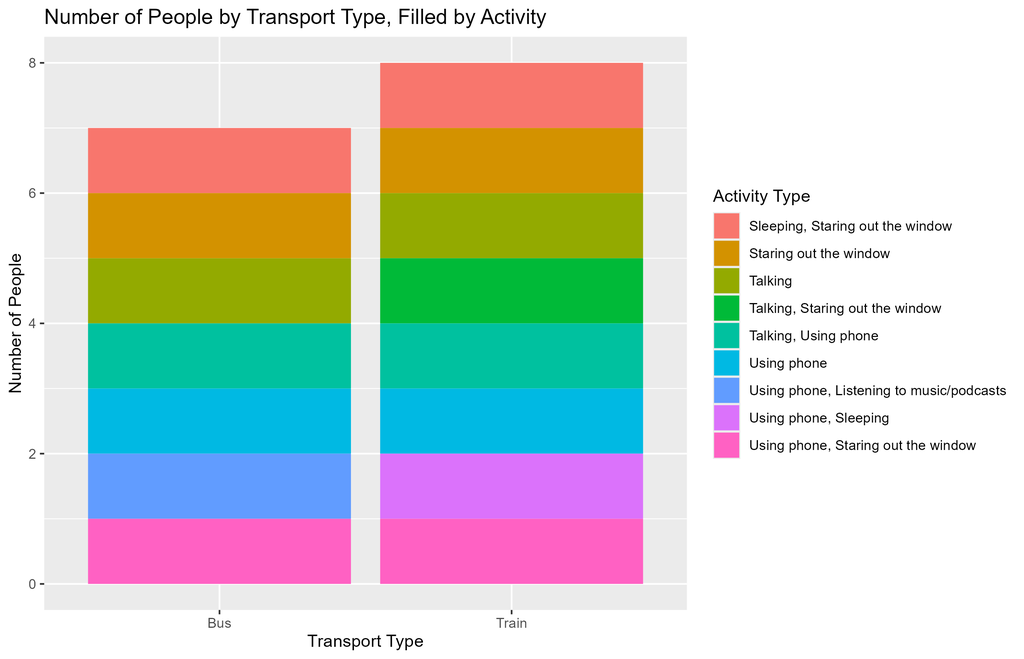

As stated before, this current graph does not show the number of people taken into account. This was why the original graph used geom_col() rather than geom_bar(). My number of people was the most difficult issue when tackling problems within this project. I originally wanted to use ages instead but as it was based off observatations and not surveys I had to us estimates for my numeric value instead.